# Predicting the Probability that a Horse Wins a Race in Hong Kong

Matthew Lewis

4/20/2020

[output not shown]

## Data Cleaning and Exploration

```r
hk$won <- as.logical(hk$won)

hk$date <- NULL

hk$position_sec5 <- NULL
hk$position_sec6 <- NULL

hk$behind_sec5 <- NULL
hk$behind_sec6 <- NULL

hk$time5.x <- NULL
hk$time6.x <- NULL

hk$sec_time5 <- NULL
hk$sec_time6 <- NULL
hk$sec_time7 <- NULL

hk$time5.y <- NULL
hk$time6.y <- NULL

hk$time7 <- NULL

hk$place_combination4 <- NULL

hk$place_dividend4 <- NULL

hk$win_combination2 <- NULL
hk$win_dividend2 <- NULL

hk$horse_gear<-NULL
hk$position_sec4<-NULL
hk$behind_sec4<-NULL
hk$time4.x<-NULL
hk$time4.y<-NULL
hk$sec_time4<-NULL
hk$place_dividend3<-NULL
hk$place_combination3<-NULL

hk$horse_ratings <- as.factor(hk$horse_ratings)
hk$place_odds[is.na(hk$place_odds)] <- mean(hk$place_odds, na.rm = TRUE)
hk$prize[is.na(hk$prize)] <- mean(hk$prize, na.rm = TRUE)
```

Here, we are cleaning our data to NULL out any mostly empty columns that will be insifnificant in our analysis. We also imputed certain columns that we found important, but had a lot of NA values. To do this, we took the mean of each column, and if a row had an NA, substituted it with the mean value.

```r
movetolast <- function(data, move) {
  data[c(setdiff(names(data), move), move)]
}

hk <- movetolast(hk, c("won"))
```

By moving our response variable (won) to the end of our data frame, we will be able to work with the data better.

```r
sapply(hk, function(x) sum(is.na(x)))
```

```
##            race_id           horse_no           horse_id             result
##                  0                  0                  0                  0
##     lengths_behind          horse_age      horse_country         horse_type
##                  0                  0                  0                  0
##       horse_rating    declared_weight      actual_weight               draw
##                  0                  0                  0                  0
##      position_sec1      position_sec2      position_sec3        behind_sec1
##                  0                  0                  0                  0
##        behind_sec2        behind_sec3            time1.x            time2.x
##                  0                  0                  0                  0
##            time3.x        finish_time           win_odds         place_odds
##                  0                  0                  0                  0
##         trainer_id          jockey_id              venue            race_no
##                  0                  0                  0                  0
##             config            surface           distance              going
##                  0                  0                  0                  0
##      horse_ratings              prize         race_class          sec_time1
##                  0                  0                  0                  0
##          sec_time2          sec_time3            time1.y            time2.y
##                  0                  0                  0                  0
##            time3.y place_combination1 place_combination2    place_dividend1
##                  0                  0                  0                  0
##    place_dividend2   win_combination1      win_dividend1                won
##                  0                  0                  0                  0
```

Checking to make sure that we properly imputed each column.

```r
hk$horse_country<-ifelse(hk$horse_country=="AUS",0,
                         ifelse(hk$horse_country=="NZ",1,
                                ifelse(hk$horse_country=="IRE",2,
                                       ifelse(hk$horse_country=="GB",3,
                                              ifelse(hk$horse_country=="USA",4,5)))))
hk$horse_type<-ifelse(hk$horse_type=="Gelding",0,1)
hk$venue<-as.numeric(hk$venue)
hk$config<-ifelse(hk$config=="A",0,
                  ifelse(hk$config=="A+3",1,
                         ifelse(hk$config=="B",2,
                                ifelse(hk$config=="B+2",3,
                                       ifelse(hk$config=="C",4,5)))))
hk$going<-ifelse(hk$going=="FAST",0,
                 ifelse(hk$going=="GOOD",1,
                        ifelse(hk$going=="GOOD TO FIRM",2,
                               ifelse(hk$going=="GOOD TO YIELDING",3,
                                      ifelse(hk$going=="SLOW",4,
                                             ifelse(hk$going=="SOFT",5,
                                                    ifelse(hk$going=="WET FAST",6,
                                                           ifelse(hk$going=="WET SLOW",7,
                                                                  ifelse(hk$going=="YIELDING",8,9)))))))))
```

For certain columns (horse_country, horst_type, venue, config, and going) with many factors, we combined certain values to make the data more manageable.

```r
str(hk)
```

```
## 'data.frame':    79447 obs. of  48 variables:
##  $ race_id           : int  0 0 0 0 0 0 0 0 0 0 ...
##  $ horse_no          : int  1 2 3 4 5 6 7 8 9 10 ...
##  $ horse_id          : int  3917 2157 858 1853 2796 3296 911 2170 1730 2998 ...
##  $ result            : int  10 8 7 9 6 3 12 1 13 14 ...
##  $ lengths_behind    : num  8 5.75 4.75 6.25 3.75 1.25 9.5 0 9.75 999 ...
##  $ horse_age         : int  3 3 3 3 3 3 3 3 3 3 ...
##  $ horse_country     : num  0 1 1 5 3 1 1 0 1 0 ...
##  $ horse_type        : num  0 0 0 0 0 0 0 0 0 1 ...
##  $ horse_rating      : int  60 60 60 60 60 60 60 60 60 60 ...
##  $ declared_weight   : num  1020 980 1082 1118 972 ...
##  $ actual_weight     : int  133 133 132 127 131 127 123 128 123 125 ...
##  $ draw              : int  7 12 8 13 14 5 11 2 6 9 ...
##  $ position_sec1     : int  6 12 3 8 13 11 1 9 2 14 ...
##  $ position_sec2     : int  4 13 2 8 12 11 1 9 3 14 ...
```

[output cut: 34 more lines]

```r
summary(hk)
```

```
##     race_id        horse_no         horse_id        result
##  Min.   :   0   Min.   : 1.000   Min.   :   0   Min.   : 1.000
##  1st Qu.:1586   1st Qu.: 4.000   1st Qu.:1085   1st Qu.: 4.000
##  Median :3174   Median : 7.000   Median :2209   Median : 7.000
##  Mean   :3173   Mean   : 6.906   Mean   :2204   Mean   : 6.839
##  3rd Qu.:4764   3rd Qu.:10.000   3rd Qu.:3308   3rd Qu.:10.000
##  Max.   :6348   Max.   :14.000   Max.   :4404   Max.   :14.000
##
##  lengths_behind      horse_age      horse_country     horse_type
##  Min.   : -0.500   Min.   : 2.000   Min.   :0.000   Min.   :0.00000
##  1st Qu.:  1.750   1st Qu.: 3.000   1st Qu.:0.000   1st Qu.:0.00000
##  Median :  4.000   Median : 3.000   Median :1.000   Median :0.00000
##  Mean   :  6.109   Mean   : 3.339   Mean   :1.147   Mean   :0.04964
##  3rd Qu.:  6.750   3rd Qu.: 3.000   3rd Qu.:2.000   3rd Qu.:0.00000
##  Max.   :999.000   Max.   :10.000   Max.   :5.000   Max.   :1.00000
##
##   horse_rating    declared_weight actual_weight        draw
##  Min.   : 10.00   Min.   : 693    Min.   :103.0   Min.   : 1.000
##  1st Qu.: 60.00   1st Qu.:1062    1st Qu.:118.0   1st Qu.: 4.000
##  Median : 60.00   Median :1102    Median :123.0   Median : 7.000
##  Mean   : 61.03   Mean   :1105    Mean   :122.7   Mean   : 6.876
##  3rd Qu.: 60.00   3rd Qu.:1146    3rd Qu.:128.0   3rd Qu.:10.000
##  Max.   :138.00   Max.   :1369    Max.   :133.0   Max.   :15.000
##
##  position_sec1   position_sec2    position_sec3     behind_sec1
##  Min.   : 1.00   Min.   : 1.000   Min.   : 1.000   Min.   :  0.150
##  1st Qu.: 4.00   1st Qu.: 4.000   1st Qu.: 4.000   1st Qu.:  1.500
##  Median : 7.00   Median : 7.000   Median : 7.000   Median :  3.000
##  Mean   : 6.85   Mean   : 6.847   Mean   : 6.843   Mean   :  3.379
##  3rd Qu.:10.00   3rd Qu.:10.000   3rd Qu.:10.000   3rd Qu.:  5.000
##  Max.   :14.00   Max.   :14.000   Max.   :14.000   Max.   :999.000
##
##   behind_sec2      behind_sec3        time1.x          time2.x
##  Min.   : 0.150   Min.   :  0.00   Min.   : 12.39   Min.   : 19.99
##  1st Qu.: 1.750   1st Qu.:  1.75   1st Qu.: 14.12   1st Qu.: 22.29
##  Median : 3.750   Median :  3.75   Median : 24.18   Median : 22.87
##  Mean   : 4.084   Mean   :  4.51   Mean   : 21.14   Mean   : 22.93
##  3rd Qu.: 5.750   3rd Qu.:  5.75   3rd Qu.: 25.36   3rd Qu.: 23.52
##  Max.   :60.250   Max.   :999.00   Max.   :999.00   Max.   :999.00
##
```

[output cut: 41 more lines]

```
##  Min.   :55.16   Min.   : 1.000     Min.   : 1.000     Min.   : 10.10
##  1st Qu.:59.74   1st Qu.: 3.000     1st Qu.: 3.000     1st Qu.: 15.00
##  Median :69.67   Median : 6.000     Median : 6.000     Median : 20.00
##  Mean   :67.22   Mean   : 6.296     Mean   : 6.427     Mean   : 28.07
##  3rd Qu.:72.04   3rd Qu.: 9.000     3rd Qu.: 9.000     3rd Qu.: 31.00
##  Max.   :81.29   Max.   :14.000     Max.   :14.000     Max.   :410.50
##
##  place_dividend2  win_combination1 win_dividend1        won
##  Min.   : 10.10   Min.   : 1.000   Min.   :  10.50   Mode :logical
##  1st Qu.: 17.00   1st Qu.: 3.000   1st Qu.:  35.00   FALSE:73087
##  Median : 24.00   Median : 6.000   Median :  59.00   TRUE :6360
##  Mean   : 33.19   Mean   : 6.297   Mean   :  97.11
##  3rd Qu.: 37.00   3rd Qu.: 9.000   3rd Qu.: 107.00
##  Max.   :627.00   Max.   :14.000   Max.   :2687.50
##
```

## Data Visualization

`r library(ggplot2) library(hrbrthemes)`

`## NOTE: Either Arial Narrow or Roboto Condensed fonts are required to use these themes.`

`## Please use hrbrthemes::import_roboto_condensed() to install Roboto Condensed and`

`## if Arial Narrow is not on your system, please see https://bit.ly/arialnarrow`

`r ggplot(hk, aes(x=horse_age, y=place_odds)) + geom_point( color="black", fill="#69b3a2", shape=22, alpha=0.5, size=6, stroke = 1 ) + theme_ipsum()`

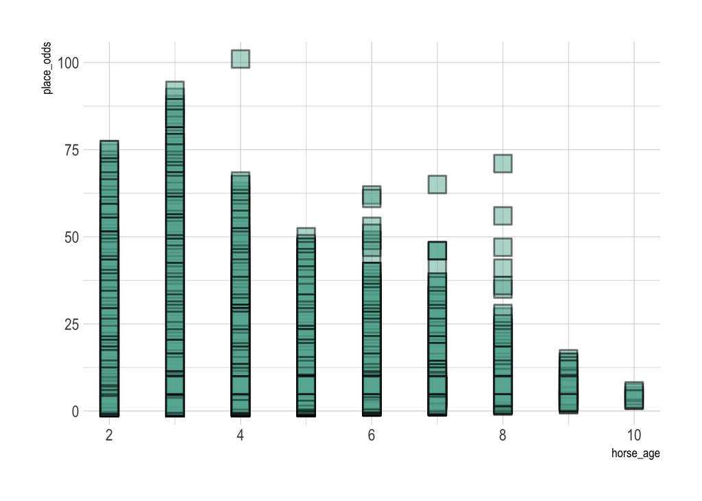

`r ggplot(hk, aes(x = actual_weight)) + stat_density()`

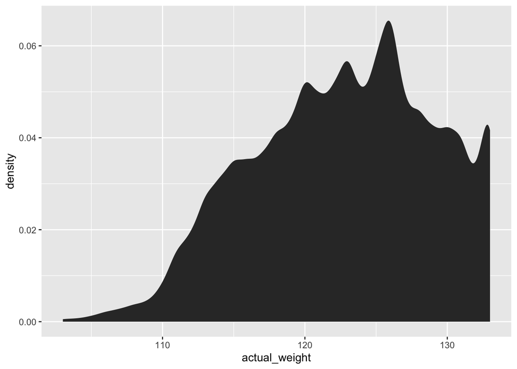

Here we can see the relationship between place odds and the age of the horse. It is clear that the higher the higher the age the lower odds it has.

`r ggplot(hk, aes(horse_age, place_odds)) + geom_jitter(aes(color = horse_age, size = 0.5))`

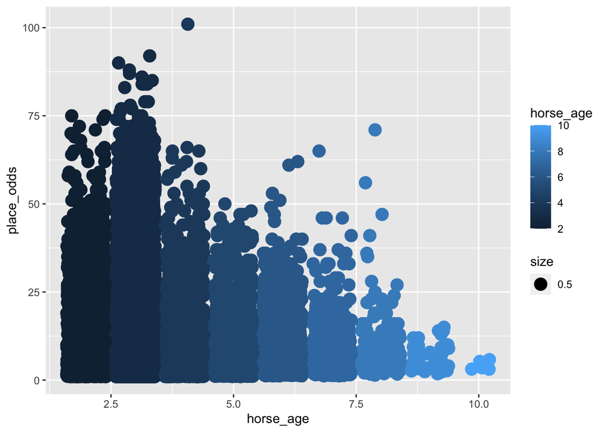

Another interesting relationship is between place odds and horse type. Most of the horses are Geldings. And it is logical to see that if the is horse is Gelding the place odds are higher.

`r ggplot(hk, aes(horse_type, place_odds)) + geom_jitter(aes(color = horse_type, size = 0.5))`

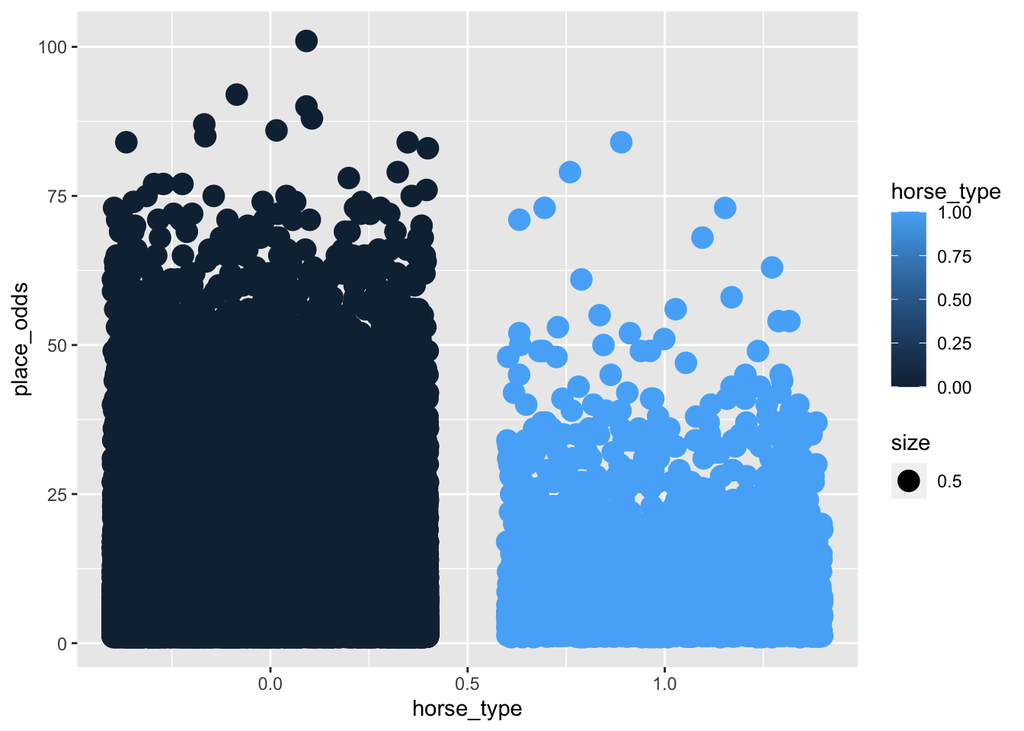

Relationship between country and place_odds. The highest place odds have horses from Ireland, Australia and New Zeland.

`r ggplot(hk, aes(horse_country, place_odds)) + geom_jitter(aes(color = horse_country, size = 0.3))`

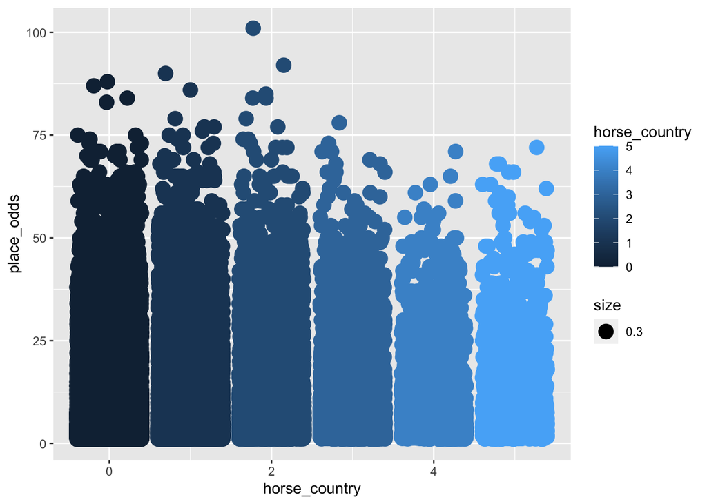

Countries represented in Hong Kong horse races.

`r table(hk$horse_country)`

`## ## 0 1 2 3 4 5 ## 29906 27497 10473 6329 2499 2743`

`r library(maptools)`

`## Loading required package: sp`

`r data(wrld_simpl) myCountries = wrld_simpl@data$NAME %in% c("Australia", "United Kingdom", "United States", "Netherlands", "New Zealand","South Africa","Argentina","France","Japan","India","Brazil","Canada","Germany","Spain","Zimbabwe","Italy","Greece") plot(wrld_simpl, col = c(gray(.90), "red")[myCountries+1],main="Countries represented")`

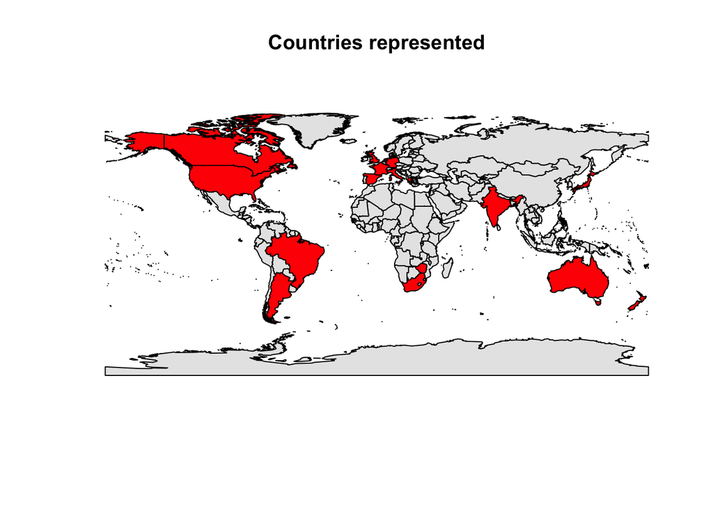

`r library(ggplot2) type_plot <- ggplot(data = hk, aes(x = result, y = lengths_behind)) type_plot + geom_jitter(alpha = 1)`

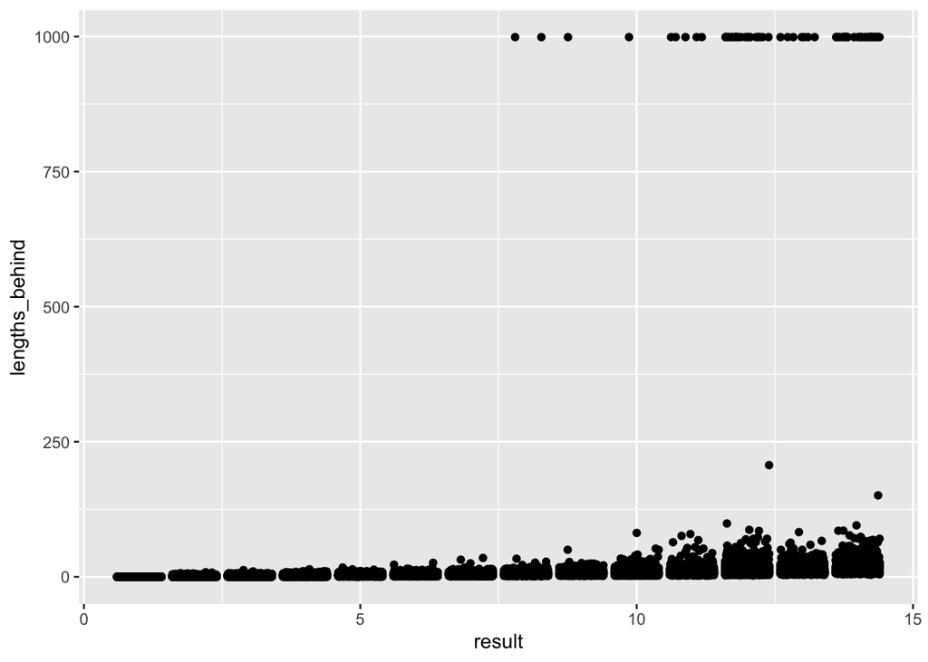

`r age_won <- table(hk$horse_age, hk$won) age_won`

`## ## FALSE TRUE ## 2 1907 191 ## 3 56452 4760 ## 4 7187 820 ## 5 4379 396 ## 6 2108 136 ## 7 794 45 ## 8 218 7 ## 9 38 3 ## 10 4 2`

`r plot(age_won) # 4 year old horses tend to win more on average than other ages`

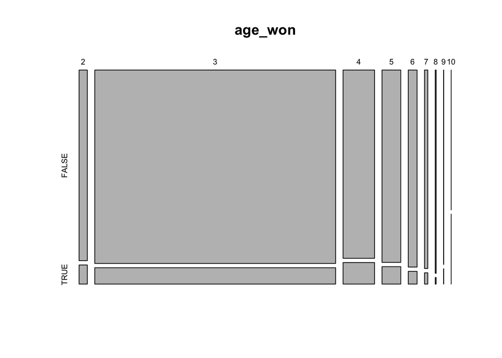

`r pos1_won <- table(hk$position_sec1, hk$won) pos1_won`

`## ## FALSE TRUE ## 1 5361 980 ## 2 5601 738 ## 3 5647 688 ## 4 5669 666 ## 5 5739 596 ## 6 5798 538 ## 7 5812 501 ## 8 5886 394 ## 9 5879 341 ## 10 5815 301 ## 11 5649 259 ## 12 5246 200 ## 13 2676 93 ## 14 2309 65`

`r plot(pos1_won) # horses in the lead at first tend to win most races`

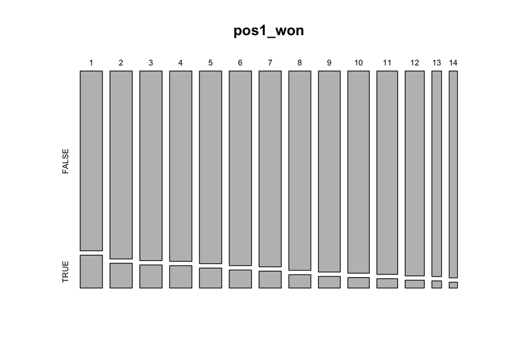

`r pos2_won <- table(hk$position_sec2, hk$won) pos2_won`

`## ## FALSE TRUE ## 1 5268 1073 ## 2 5638 705 ## 3 5563 780 ## 4 5665 676 ## 5 5717 622 ## 6 5772 562 ## 7 5849 468 ## 8 5888 398 ## 9 5926 296 ## 10 5838 273 ## 11 5708 201 ## 12 5249 182 ## 13 2700 68 ## 14 2306 56`

`r plot(pos2_won)`

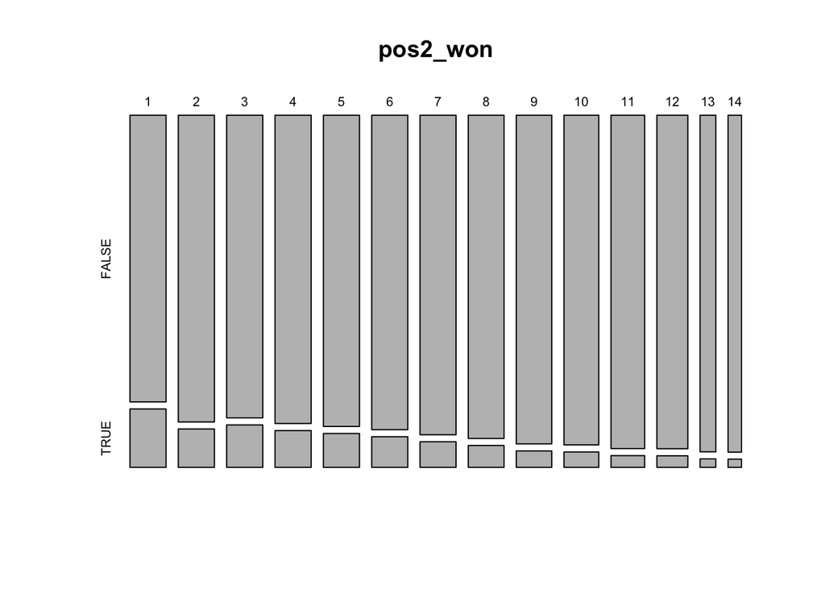

`r pos3_won <- table(hk$position_sec3, hk$won) pos3_won`

`## ## FALSE TRUE ## 1 3125 3225 ## 2 5990 355 ## 3 5880 471 ## 4 5966 381 ## 5 5972 363 ## 6 5986 352 ## 7 5998 314 ## 8 6032 259 ## 9 6032 189 ## 10 5943 174 ## 11 5780 126 ## 12 5334 84 ## 13 2725 45 ## 14 2324 22`

`r plot(pos3_won) # by the third turn, there is a greater than 50% chance that the lead horse wins the race`

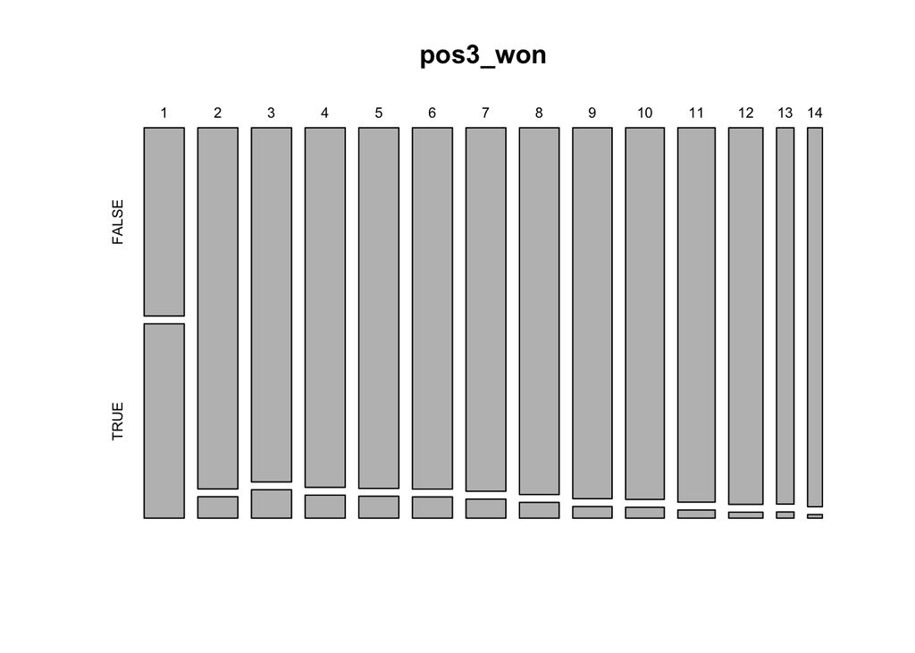

`r country_won <- table(hk$horse_country, hk$won) country_won`

`## ## FALSE TRUE ## 0 27389 2517 ## 1 25226 2271 ## 2 9724 749 ## 3 5856 473 ## 4 2320 179 ## 5 2572 171`

[figure not shown]

Above is some visualizations of our data with comments explaining the results. No data graphics were particularly surprising, so we are going to weigh the results of our predictive models more heavily.

## Logistic Regression Models

### Logistic Regression

```r
logistic1 <- glm(won ~ place_odds + position_sec1 + position_sec2 + position_sec3 + distance, data = hk, family = "binomial")
summary(logistic1)
```

```
##
## Call:
## glm(formula = won ~ place_odds + position_sec1 + position_sec2 +
##     position_sec3 + distance, family = "binomial", data = hk)
##
## Deviance Residuals:
##     Min       1Q   Median       3Q      Max
## -1.5220  -0.4322  -0.2181  -0.0771   4.9932
##
## Coefficients:
##                 Estimate Std. Error z value Pr(>|z|)
## (Intercept)   -9.877e-01  8.204e-02 -12.039   <2e-16 ***
## place_odds    -2.550e-01  6.873e-03 -37.102   <2e-16 ***
## position_sec1 -7.499e-03  1.076e-02  -0.697    0.486
## position_sec2  1.554e-01  1.217e-02  12.770   <2e-16 ***
## position_sec3 -4.328e-01  7.491e-03 -57.770   <2e-16 ***
## distance       6.392e-04  5.264e-05  12.143   <2e-16 ***
## ---
## Signif. codes:  0 '***' 0.001 '**' 0.01 '*' 0.05 '.' 0.1 ' ' 1
##
## (Dispersion parameter for binomial family taken to be 1)
##
##     Null deviance: 44315  on 79446  degrees of freedom
## Residual deviance: 34525  on 79441  degrees of freedom
## AIC: 34537
##
## Number of Fisher Scoring iterations: 8
```

```r
logistic2 <- glm(won ~ place_odds + position_sec1 + position_sec2 + position_sec3 + horse_age + declared_weight, data = hk, family = "binomial")
summary(logistic2)
```

```
##
## Call:
## glm(formula = won ~ place_odds + position_sec1 + position_sec2 +
##     position_sec3 + horse_age + declared_weight, family = "binomial",
##     data = hk)
##
## Deviance Residuals:
##     Min       1Q   Median       3Q      Max
## -1.3893  -0.4326  -0.2224  -0.0833   4.9445
##
## Coefficients:
##                   Estimate Std. Error z value Pr(>|z|)
## (Intercept)      0.0324619  0.2695796   0.120    0.904
## place_odds      -0.2486359  0.0068370 -36.366   <2e-16 ***
## position_sec1   -0.0158325  0.0107221  -1.477    0.140
## position_sec2    0.1408821  0.0120165  11.724   <2e-16 ***
## position_sec3   -0.4073410  0.0070099 -58.109   <2e-16 ***
## horse_age        0.0238434  0.0169803   1.404    0.160
## declared_weight -0.0001745  0.0002328  -0.750    0.453
## ---
## Signif. codes:  0 '***' 0.001 '**' 0.01 '*' 0.05 '.' 0.1 ' ' 1
##
## (Dispersion parameter for binomial family taken to be 1)
##
##     Null deviance: 44315  on 79446  degrees of freedom
## Residual deviance: 34669  on 79440  degrees of freedom
## AIC: 34683
##
## Number of Fisher Scoring iterations: 8
```

```r
logistic3 <- glm(won ~ place_odds + position_sec1 + position_sec2 + position_sec3 +  horse_country, data = hk, family = "binomial")
summary(logistic3)
```

```
##
## Call:
## glm(formula = won ~ place_odds + position_sec1 + position_sec2 +
##     position_sec3 + horse_country, family = "binomial", data = hk)
##
## Deviance Residuals:
##     Min       1Q   Median       3Q      Max
## -1.3780  -0.4326  -0.2226  -0.0835   4.9416
##
## Coefficients:
##                Estimate Std. Error z value Pr(>|z|)
## (Intercept)   -0.105000   0.035384  -2.967   0.0030 **
## place_odds    -0.248053   0.006794 -36.509   <2e-16 ***
## position_sec1 -0.015809   0.010720  -1.475   0.1403
## position_sec2  0.141068   0.012014  11.742   <2e-16 ***
## position_sec3 -0.407617   0.007011 -58.143   <2e-16 ***
## horse_country  0.019885   0.011558   1.720   0.0854 .
## ---
## Signif. codes:  0 '***' 0.001 '**' 0.01 '*' 0.05 '.' 0.1 ' ' 1
##
## (Dispersion parameter for binomial family taken to be 1)
##
##     Null deviance: 44315  on 79446  degrees of freedom
## Residual deviance: 34669  on 79441  degrees of freedom
## AIC: 34681
##
## Number of Fisher Scoring iterations: 8
```

```r
logistic4 <- glm(won ~ place_odds + position_sec1 + position_sec2 + position_sec3 +  horse_type, data = hk, family = "binomial")
summary(logistic4)
```

```
##
## Call:
## glm(formula = won ~ place_odds + position_sec1 + position_sec2 +
##     position_sec3 + horse_type, family = "binomial", data = hk)
##
## Deviance Residuals:
##     Min       1Q   Median       3Q      Max
## -1.3841  -0.4323  -0.2226  -0.0837   4.9337
##
## Coefficients:
##                Estimate Std. Error z value Pr(>|z|)
## (Intercept)   -0.091674   0.033957  -2.700  0.00694 **
## place_odds    -0.247440   0.006780 -36.495  < 2e-16 ***
## position_sec1 -0.015909   0.010719  -1.484  0.13776
## position_sec2  0.141090   0.012011  11.747  < 2e-16 ***
## position_sec3 -0.407204   0.007001 -58.162  < 2e-16 ***
## horse_type     0.097894   0.064471   1.518  0.12891
## ---
## Signif. codes:  0 '***' 0.001 '**' 0.01 '*' 0.05 '.' 0.1 ' ' 1
##
## (Dispersion parameter for binomial family taken to be 1)
##
##     Null deviance: 44315  on 79446  degrees of freedom
## Residual deviance: 34669  on 79441  degrees of freedom
## AIC: 34681
##
## Number of Fisher Scoring iterations: 8
```

```r
logistic5 <- glm(won ~ place_odds + position_sec1 + position_sec2 + position_sec3 +  horse_ratings, data = hk, family = "binomial")
summary(logistic5)
```

```
##
## Call:
## glm(formula = won ~ place_odds + position_sec1 + position_sec2 +
##     position_sec3 + horse_ratings, family = "binomial", data = hk)
##
## Deviance Residuals:
##     Min       1Q   Median       3Q      Max
## -1.3988  -0.4326  -0.2224  -0.0834   4.9416
##
## Coefficients:
##                       Estimate Std. Error z value Pr(>|z|)
## (Intercept)          -0.030722   0.353761  -0.087    0.931
## place_odds           -0.248190   0.006795 -36.526   <2e-16 ***
## position_sec1        -0.015555   0.010723  -1.451    0.147
## position_sec2         0.141507   0.012020  11.773   <2e-16 ***
## position_sec3        -0.407984   0.007016 -58.150   <2e-16 ***
## horse_ratings100-80  -0.045296   0.356895  -0.127    0.899
## horse_ratings100+     0.195527   0.496130   0.394    0.694
## horse_ratings105-80  -0.072877   0.363884  -0.200    0.841
## horse_ratings105-85   0.052287   0.861033   0.061    0.952
## horse_ratings110-80  -0.063491   1.209846  -0.052    0.958
## horse_ratings110-85  -0.055285   0.389309  -0.142    0.887
## horse_ratings110-90   0.112867   0.424963   0.266    0.791
## horse_ratings115-90  -0.054740   0.396697  -0.138    0.890
## horse_ratings115-95   0.168436   0.485801   0.347    0.729
## horse_ratings120-100 -0.177955   0.671890  -0.265    0.791
## horse_ratings120-95  -0.215574   0.513792  -0.420    0.675
## horse_ratings40-0    -0.013185   0.358896  -0.037    0.971
## horse_ratings40-10   -0.056883   0.361727  -0.157    0.875
## horse_ratings40-15    0.004286   0.356823   0.012    0.990
## horse_ratings40-20   -0.018942   0.421204  -0.045    0.964
## horse_ratings60-35    0.099318   0.396298   0.251    0.802
## horse_ratings60-40   -0.074053   0.353321  -0.210    0.834
## horse_ratings65-40   -0.068192   0.379947  -0.179    0.858
## horse_ratings75-55    0.146609   0.657979   0.223    0.824
## horse_ratings80-55    0.209124   0.468720   0.446    0.655
## horse_ratings80-60   -0.072894   0.353518  -0.206    0.837
## horse_ratings80+      0.039661   0.608248   0.065    0.948
## horse_ratings85-60   -0.095785   0.361699  -0.265    0.791
## horse_ratings85+      0.124073   0.720116   0.172    0.863
## horse_ratings90-70   -0.062218   0.431416  -0.144    0.885
## horse_ratings90+     -0.051812   0.405861  -0.128    0.898
## horse_ratings95-70    0.910309   1.129939   0.806    0.420
## horse_ratings95-75    0.013767   0.383459   0.036    0.971
## horse_ratings95+     -0.178324   0.421306  -0.423    0.672
## horse_ratingsG        0.037360   0.358289   0.104    0.917
## ---
## Signif. codes:  0 '***' 0.001 '**' 0.01 '*' 0.05 '.' 0.1 ' ' 1
##
## (Dispersion parameter for binomial family taken to be 1)
##
##     Null deviance: 44315  on 79446  degrees of freedom
## Residual deviance: 34662  on 79412  degrees of freedom
## AIC: 34732
##
## Number of Fisher Scoring iterations: 8
```

```r
logistic6 <- glm(won ~ place_odds +  distance + horse_age + declared_weight + horse_country + horse_type, data = hk, family = "binomial")
summary(logistic6)
```

```
##
## Call:
## glm(formula = won ~ place_odds + distance + horse_age + declared_weight +
##     horse_country + horse_type, family = "binomial", data = hk)
##
## Deviance Residuals:
##     Min       1Q   Median       3Q      Max
## -0.7351  -0.5104  -0.3455  -0.1358   5.4088
##
## Coefficients:
##                   Estimate Std. Error z value Pr(>|z|)
## (Intercept)     -2.139e+00  2.712e-01  -7.888 3.08e-15 ***
## place_odds      -3.257e-01  7.060e-03 -46.133  < 2e-16 ***
## distance        -4.274e-05  4.878e-05  -0.876   0.3809
## horse_age        3.608e-02  1.646e-02   2.192   0.0284 *
## declared_weight  9.144e-04  2.237e-04   4.088 4.35e-05 ***
## horse_country   -9.326e-03  1.147e-02  -0.813   0.4164
## horse_type       5.728e-02  6.167e-02   0.929   0.3530
## ---
## Signif. codes:  0 '***' 0.001 '**' 0.01 '*' 0.05 '.' 0.1 ' ' 1
##
## (Dispersion parameter for binomial family taken to be 1)
##
##     Null deviance: 44315  on 79446  degrees of freedom
## Residual deviance: 39547  on 79440  degrees of freedom
## AIC: 39561
##
## Number of Fisher Scoring iterations: 8
```

```r
logistic7 <- glm(won ~ distance + horse_age + declared_weight + horse_country + horse_type, data = hk, family = "binomial")
summary(logistic7)
```

```
##
## Call:
## glm(formula = won ~ distance + horse_age + declared_weight +
##     horse_country + horse_type, family = "binomial", data = hk)
##
## Deviance Residuals:
##     Min       1Q   Median       3Q      Max
## -0.5151  -0.4223  -0.4051  -0.3862   2.4148
##
## Coefficients:
##                   Estimate Std. Error z value Pr(>|z|)
## (Intercept)     -4.175e+00  2.554e-01 -16.344  < 2e-16 ***
## distance         6.632e-05  4.802e-05   1.381    0.167
## horse_age       -1.192e-02  1.534e-02  -0.777    0.437
## declared_weight  1.559e-03  2.125e-04   7.337 2.18e-13 ***
## horse_country   -4.579e-02  1.102e-02  -4.153 3.28e-05 ***
## horse_type       4.999e-02  5.999e-02   0.833    0.405
## ---
## Signif. codes:  0 '***' 0.001 '**' 0.01 '*' 0.05 '.' 0.1 ' ' 1
##
## (Dispersion parameter for binomial family taken to be 1)
##
##     Null deviance: 44315  on 79446  degrees of freedom
## Residual deviance: 44229  on 79441  degrees of freedom
## AIC: 44241
##
## Number of Fisher Scoring iterations: 5
```

[output not shown]

### kNN

```r
library(class)
hk_norm_pred <- knn(train = train_x, test = test_x, cl = train_y, k = 7) # no missing values are allowed
library(gmodels)
CrossTable(x = test_y, y = hk_norm_pred, prop.chisq = FALSE)
```

```
##
##
##    Cell Contents
## |-------------------------|
## |                       N |
## |           N / Row Total |
## |           N / Col Total |
## |         N / Table Total |
## |-------------------------|
##
##
## Total Observations in Table:  19447
##
##
##              | hk_norm_pred
##       test_y |         0 |         1 | Row Total |
## -------------|-----------|-----------|-----------|
##            0 |     17762 |       133 |     17895 |
##              |     0.993 |     0.007 |     0.920 |
##              |     0.938 |     0.259 |           |
##              |     0.913 |     0.007 |           |
## -------------|-----------|-----------|-----------|
##            1 |      1172 |       380 |      1552 |
##              |     0.755 |     0.245 |     0.080 |
##              |     0.062 |     0.741 |           |
##              |     0.060 |     0.020 |           |
## -------------|-----------|-----------|-----------|
## Column Total |     18934 |       513 |     19447 |
##              |     0.974 |     0.026 |           |
## -------------|-----------|-----------|-----------|
##
##
```

```r
library(caret)
confusionMatrix(factor(hk_norm_pred), factor(test_y))
```

```
## Confusion Matrix and Statistics
##
##           Reference
## Prediction     0     1
##          0 17762  1172
##          1   133   380
##
##                Accuracy : 0.9329
##                  95% CI : (0.9293, 0.9364)
##     No Information Rate : 0.9202
##     P-Value [Acc > NIR] : 1.128e-11
##
##                   Kappa : 0.3419
##
##  Mcnemar's Test P-Value : < 2.2e-16
##
##             Sensitivity : 0.9926
##             Specificity : 0.2448
##          Pos Pred Value : 0.9381
##          Neg Pred Value : 0.7407
##              Prevalence : 0.9202
##          Detection Rate : 0.9134
##    Detection Prevalence : 0.9736
##       Balanced Accuracy : 0.6187
##
##        'Positive' Class : 0
##
```

#### Improving kNN

```r
library(C50)

knn_boost10 <- C5.0(alpha_train[-1], as.factor(alpha_train$won),
                       trials = 10)
knn_boost10
```

```
##
## Call:
## C5.0.default(x = alpha_train[-1], y = as.factor(alpha_train$won), trials = 10)
##
## Classification Tree
## Number of samples: 60000
## Number of predictors: 77
##
## Number of boosting iterations: 10 requested;  1 used due to early stopping
##
## Non-standard options: attempt to group attributes
```

```r
summary(knn_boost10)
```

```
##
## Call:
## C5.0.default(x = alpha_train[-1], y = as.factor(alpha_train$won), trials = 10)
##
##
## C5.0 [Release 2.07 GPL Edition]      Fri Apr 17 15:31:25 2020
## -------------------------------
##
## Class specified by attribute `outcome'
##
## Read 60000 cases (78 attributes) from undefined.data
##
## -----  Trial 0:  -----
##
## Decision tree:
##
## wonTRUE <= 0: 0 (55192)
## wonTRUE > 0: 1 (4808)
##
## *** boosting reduced to 1 trial since last classifier is very accurate
##
## *** boosting abandoned (too few classifiers)
##
##
## Evaluation on training data (60000 cases):
##
##      Decision Tree
##    ----------------
##    Size      Errors
##
##       2    0( 0.0%)   <<
##
##
##     (a)   (b)    <-classified as
##    ----  ----
##   55192          (a): class 0
##          4808    (b): class 1
##
##
##  Attribute usage:
##
##  100.00% wonTRUE
##
##
## Time: 1.2 secs
```

```r
knn_boost_pred10 <- predict(knn_boost10, alpha_test)
CrossTable(alpha_test$won, knn_boost_pred10,
           prop.chisq = FALSE, prop.c = FALSE, prop.r = FALSE,
           dnn = c('actual won', 'predicted won'))
```

```
##
##
##    Cell Contents
## |-------------------------|
## |                       N |
## |         N / Table Total |
## |-------------------------|
##
##
## Total Observations in Table:  19447
##
##
##              | predicted won
##   actual won |         0 |         1 | Row Total |
## -------------|-----------|-----------|-----------|
##            0 |     17895 |         0 |     17895 |
##              |     0.920 |     0.000 |           |
## -------------|-----------|-----------|-----------|
##            1 |         0 |      1552 |      1552 |
##              |     0.000 |     0.080 |           |
## -------------|-----------|-----------|-----------|
## Column Total |     17895 |      1552 |     19447 |
## -------------|-----------|-----------|-----------|
##
##
```

```r
## Making some mistakes more costly than others
# create a cost matrix
knn_error_cost <- matrix(c(0, 1, 4, 0), nrow = 2)
knn_error_cost
```

```
##      [,1] [,2]
## [1,]    0    4
## [2,]    1    0
```

```r
# apply the cost matrix to the tree
knn_cost <- C5.0(alpha_train[-1], as.factor(alpha_train$won),
                          costs = knn_error_cost)
knn_cost_pred <- predict(knn_cost, alpha_test)

CrossTable(alpha_test$won, knn_cost_pred,
           prop.chisq = FALSE, prop.c = FALSE, prop.r = FALSE,
           dnn = c('actual won', 'predicted won'))
```

```
##
##
##    Cell Contents
## |-------------------------|
## |                       N |
## |         N / Table Total |
## |-------------------------|
##
##
## Total Observations in Table:  19447
##
##
##              | predicted won
##   actual won |         0 |         1 | Row Total |
## -------------|-----------|-----------|-----------|
##            0 |     17895 |         0 |     17895 |
##              |     0.920 |     0.000 |           |
## -------------|-----------|-----------|-----------|
##            1 |         0 |      1552 |      1552 |
##              |     0.000 |     0.080 |           |
## -------------|-----------|-----------|-----------|
## Column Total |     17895 |      1552 |     19447 |
## -------------|-----------|-----------|-----------|
##
##
```

### SVM

```r
# normalizing data
hk_norm_svm <- as.data.frame(model.matrix(~.-1, hk))

normalize <- function(x) {
  return ((x - min(x)) / (max(x) - min(x)))
}
```

```r
hk_norm_svm <- as.data.frame(lapply(hk_norm_svm[1:78], normalize))
```

```r
svm_train <- hk_norm_svm[1:60000, ]
svm_test <- hk_norm_svm[60001:79447, ]

library(kernlab)
hk_classifier <- ksvm(wonTRUE ~ ., data = svm_train, kernel = "rbfdot")
hk_predict <- predict(hk_classifier, svm_test)

svm_test$wonTRUE <- as.matrix(as.factor(svm_test$wonTRUE))
hk_predict <- ifelse(hk_predict < 0.22, 0, 1)

table(hk_predict, svm_test$wonTRUE)
```

```
##
## hk_predict     0     1
##          0 17894  1456
##          1     1    96
```

```r
hk_predict = factor(hk_predict, levels = c(0, 1))
svm_test$wonTRUE = factor(svm_test$wonTRUE, levels = c(0, 1))

confusionMatrix(hk_predict, svm_test$wonTRUE)
```

```
## Confusion Matrix and Statistics
##
##           Reference
## Prediction     0     1
##          0 17894  1456
##          1     1    96
##
##                Accuracy : 0.9251
##                  95% CI : (0.9213, 0.9287)
##     No Information Rate : 0.9202
##     P-Value [Acc > NIR] : 0.005857
##
##                   Kappa : 0.1081
##
##  Mcnemar's Test P-Value : < 2.2e-16
##
##             Sensitivity : 0.99994
##             Specificity : 0.06186
##          Pos Pred Value : 0.92475
##          Neg Pred Value : 0.98969
##              Prevalence : 0.92019
##          Detection Rate : 0.92014
##    Detection Prevalence : 0.99501
##       Balanced Accuracy : 0.53090
##
##        'Positive' Class : 0
##
```

#### Improving SVM

```r
library(C50)

svm_boost10 <- C5.0(svm_train[-1], as.factor(svm_train$wonTRUE),
                       trials = 10)
svm_boost10
```

```
##
## Call:
## C5.0.default(x = svm_train[-1], y = as.factor(svm_train$wonTRUE), trials = 10)
##
## Classification Tree
## Number of samples: 60000
## Number of predictors: 77
##
## Number of boosting iterations: 10 requested;  1 used due to early stopping
##
## Non-standard options: attempt to group attributes
```

```r
summary(svm_boost10)
```

```
##
## Call:
## C5.0.default(x = svm_train[-1], y = as.factor(svm_train$wonTRUE), trials = 10)
##
##
## C5.0 [Release 2.07 GPL Edition]      Fri Apr 17 16:08:22 2020
## -------------------------------
##
## Class specified by attribute `outcome'
##
## Read 60000 cases (78 attributes) from undefined.data
##
## -----  Trial 0:  -----
##
## Decision tree:
##
## wonTRUE <= 0: 0 (55192)
## wonTRUE > 0: 1 (4808)
##
## *** boosting reduced to 1 trial since last classifier is very accurate
##
## *** boosting abandoned (too few classifiers)
##
##
## Evaluation on training data (60000 cases):
##
##      Decision Tree
##    ----------------
##    Size      Errors
##
##       2    0( 0.0%)   <<
##
##
##     (a)   (b)    <-classified as
##    ----  ----
##   55192          (a): class 0
##          4808    (b): class 1
##
##
##  Attribute usage:
##
##  100.00% wonTRUE
##
##
## Time: 1.2 secs
```

```r
svm_boost_pred10 <- predict(svm_boost10, svm_test)
CrossTable(svm_test$won, svm_boost_pred10,
           prop.chisq = FALSE, prop.c = FALSE, prop.r = FALSE,
           dnn = c('actual won', 'predicted won'))
```

```
##
##
##    Cell Contents
## |-------------------------|
## |                       N |
## |         N / Table Total |
## |-------------------------|
##
##
## Total Observations in Table:  19447
##
##
##              | predicted won
##   actual won |         0 |         1 | Row Total |
## -------------|-----------|-----------|-----------|
##            0 |     17895 |         0 |     17895 |
##              |     0.920 |     0.000 |           |
## -------------|-----------|-----------|-----------|
##            1 |         0 |      1552 |      1552 |
##              |     0.000 |     0.080 |           |
## -------------|-----------|-----------|-----------|
## Column Total |     17895 |      1552 |     19447 |
## -------------|-----------|-----------|-----------|
##
##
```

```r
## Making some mistakes more costly than others
# create a cost matrix
svm_error_cost <- matrix(c(0, 1, 4, 0), nrow = 2)
svm_error_cost
```

```
##      [,1] [,2]
## [1,]    0    4
## [2,]    1    0
```

```r
# apply the cost matrix to the tree
svm_cost <- C5.0(svm_train[-1], as.factor(svm_train$won),
                          costs = svm_error_cost)
svm_cost_pred <- predict(svm_cost, svm_test)

CrossTable(svm_test$won, svm_cost_pred,
           prop.chisq = FALSE, prop.c = FALSE, prop.r = FALSE,
           dnn = c('actual won', 'predicted won'))
```

```
##
##
##    Cell Contents
## |-------------------------|
## |                       N |
## |         N / Table Total |
## |-------------------------|
##
##
## Total Observations in Table:  19447
##
##
##              | predicted won
##   actual won |         0 |         1 | Row Total |
## -------------|-----------|-----------|-----------|
##            0 |     17895 |         0 |     17895 |
##              |     0.920 |     0.000 |           |
## -------------|-----------|-----------|-----------|
##            1 |         0 |      1552 |      1552 |
##              |     0.000 |     0.080 |           |
## -------------|-----------|-----------|-----------|
## Column Total |     17895 |      1552 |     19447 |
## -------------|-----------|-----------|-----------|
##
##
```

### ANN

```r
library(neuralnet)

hk_ann <- hk

# normalizing data
hk_ann <- as.data.frame(model.matrix(~.-1, hk_ann))

normalize <- function(x) {
  return ((x - min(x)) / (max(x) - min(x)))
}
hk_ann <- as.data.frame(lapply(hk_ann[1:ncol(hk_ann)], normalize))

hk_train_ann <- hk_ann[1:60000, ]
hk_test_ann <- hk_ann[60001:79447, ]
```

```r
hk_model_ann <- neuralnet(formula = wonTRUE ~ ., data = hk_train_ann)

plot(hk_model_ann)
```

[output not shown]

```r
model_results <- compute(hk_model_ann, hk_test_ann)
predicted_won <- model_results$net.result
summary(predicted_won)
```

```
##        V1
##  Min.   :0.0000003
##  1st Qu.:0.0000003
##  Median :0.0000003
##  Mean   :0.0798121
##  3rd Qu.:0.0000003
##  Max.   :1.0086106
```

```r
cor(predicted_won, hk_test_ann$wonTRUE)
```

```
##           [,1]
## [1,] 0.9999995
```

```r
binary_ps <- ifelse(predicted_won > 0.062, 1, 0)

library(caret)
confusionMatrix(as.factor(binary_ps), as.factor(hk_test_ann$wonTRUE))
```

```
## Confusion Matrix and Statistics
##
##           Reference
## Prediction     0     1
##          0 17895     0
##          1     0  1552
##
##                Accuracy : 1
##                  95% CI : (0.9998, 1)
##     No Information Rate : 0.9202
##     P-Value [Acc > NIR] : < 2.2e-16
##
##                   Kappa : 1
##
##  Mcnemar's Test P-Value : NA
##
##             Sensitivity : 1.0000
##             Specificity : 1.0000
##          Pos Pred Value : 1.0000
##          Neg Pred Value : 1.0000
##              Prevalence : 0.9202
##          Detection Rate : 0.9202
##    Detection Prevalence : 0.9202
##       Balanced Accuracy : 1.0000
##
##        'Positive' Class : 0
##
```

With just one node, our ANN model had a 100% accuracy rate.

```r
hk_model_ann2 <- neuralnet(formula = wonTRUE ~ ., data = hk_train_ann, hidden = 3, threshold = 0.2)
```

```r
# plot the network
plot(hk_model_ann2)
```

[output not shown]

```r
# evaluate the results as we did before
model_results2 <- compute(hk_model_ann2, hk_test_ann)
predicted_won2 <- model_results2$net.result
summary(predicted_won2)
```

```
##        V1
##  Min.   :-0.0102193
##  1st Qu.:-0.0000018
##  Median :-0.0000018
##  Mean   : 0.0798584
##  3rd Qu.:-0.0000018
##  Max.   : 1.1357642
```

```r
cor(predicted_won2, hk_test_ann$wonTRUE)
```

```
##           [,1]
## [1,] 0.9999526
```

```r
binary_ps2 <- ifelse(predicted_won2 > 0.062, 1, 0)

library(caret)
confusionMatrix(as.factor(binary_ps2), as.factor(hk_test_ann$wonTRUE))
```

```
## Confusion Matrix and Statistics
##
##           Reference
## Prediction     0     1
##          0 17895     0
##          1     0  1552
##
##                Accuracy : 1
##                  95% CI : (0.9998, 1)
##     No Information Rate : 0.9202
##     P-Value [Acc > NIR] : < 2.2e-16
##
##                   Kappa : 1
##
##  Mcnemar's Test P-Value : NA
##
##             Sensitivity : 1.0000
##             Specificity : 1.0000
##          Pos Pred Value : 1.0000
##          Neg Pred Value : 1.0000
##              Prevalence : 0.9202
##          Detection Rate : 0.9202
##    Detection Prevalence : 0.9202
##       Balanced Accuracy : 1.0000
##
##        'Positive' Class : 0
##
```

After adding 2 more nodes to have 3 total, we found our accuracy rate to still be 100%.

#### Improving ANN

```r
library(C50)

ann_boost10 <- C5.0(hk_train_ann[-1], as.factor(hk_train_ann$wonTRUE),
                       trials = 10)
ann_boost10
```

```
##
## Call:
## C5.0.default(x = hk_train_ann[-1], y = as.factor(hk_train_ann$wonTRUE),
##  trials = 10)
##
## Classification Tree
## Number of samples: 60000
## Number of predictors: 77
##
## Number of boosting iterations: 10 requested;  1 used due to early stopping
##
## Non-standard options: attempt to group attributes
```

```r
summary(ann_boost10)
```

```
##
## Call:
## C5.0.default(x = hk_train_ann[-1], y = as.factor(hk_train_ann$wonTRUE),
##  trials = 10)
##
##
## C5.0 [Release 2.07 GPL Edition]      Fri Apr 17 16:17:02 2020
## -------------------------------
##
## Class specified by attribute `outcome'
##
## Read 60000 cases (78 attributes) from undefined.data
##
## -----  Trial 0:  -----
##
## Decision tree:
##
## wonTRUE <= 0: 0 (55192)
## wonTRUE > 0: 1 (4808)
##
## *** boosting reduced to 1 trial since last classifier is very accurate
##
## *** boosting abandoned (too few classifiers)
##
##
## Evaluation on training data (60000 cases):
##
##      Decision Tree
##    ----------------
##    Size      Errors
##
##       2    0( 0.0%)   <<
##
##
##     (a)   (b)    <-classified as
##    ----  ----
##   55192          (a): class 0
##          4808    (b): class 1
##
##
##  Attribute usage:
##
##  100.00% wonTRUE
##
##
## Time: 1.2 secs
```

```r
ann_boost_pred10 <- predict(ann_boost10, hk_test_ann)
CrossTable(hk_test_ann$wonTRUE, ann_boost_pred10,
           prop.chisq = FALSE, prop.c = FALSE, prop.r = FALSE,
           dnn = c('actual won', 'predicted won'))
```

```
##
##
##    Cell Contents
## |-------------------------|
## |                       N |
## |         N / Table Total |
## |-------------------------|
##
##
## Total Observations in Table:  19447
##
##
##              | predicted won
##   actual won |         0 |         1 | Row Total |
## -------------|-----------|-----------|-----------|
##            0 |     17895 |         0 |     17895 |
##              |     0.920 |     0.000 |           |
## -------------|-----------|-----------|-----------|
##            1 |         0 |      1552 |      1552 |
##              |     0.000 |     0.080 |           |
## -------------|-----------|-----------|-----------|
## Column Total |     17895 |      1552 |     19447 |
## -------------|-----------|-----------|-----------|
##
##
```

```r
## Making some mistakes more costly than others
# create a cost matrix
ann_error_cost <- matrix(c(0, 1, 4, 0), nrow = 2)
ann_error_cost
```

```
##      [,1] [,2]
## [1,]    0    4
## [2,]    1    0
```

```r
# apply the cost matrix to the tree
ann_cost <- C5.0(hk_train_ann[-1], as.factor(hk_train_ann$wonTRUE),
                          costs = ann_error_cost)
ann_cost_pred <- predict(ann_cost, hk_test_ann)

CrossTable(hk_test_ann$wonTRUE, ann_cost_pred,
           prop.chisq = FALSE, prop.c = FALSE, prop.r = FALSE,
           dnn = c('actual won', 'predicted won'))
```

```
##
##
##    Cell Contents
## |-------------------------|
## |                       N |
## |         N / Table Total |
## |-------------------------|
##
##
## Total Observations in Table:  19447
##
##
##              | predicted won
##   actual won |         0 |         1 | Row Total |
## -------------|-----------|-----------|-----------|
##            0 |     17895 |         0 |     17895 |
##              |     0.920 |     0.000 |           |
## -------------|-----------|-----------|-----------|
##            1 |         0 |      1552 |      1552 |
##              |     0.000 |     0.080 |           |
## -------------|-----------|-----------|-----------|
## Column Total |     17895 |      1552 |     19447 |
## -------------|-----------|-----------|-----------|
##
##
```

### Combined Model

```r
# combining data
combined_hk <- data.frame(as.numeric(hk_norm_pred), as.numeric(hk_predict), as.numeric(predicted_won2), hk_test_ann$wonTRUE)
combined_hk$weighted <- ifelse(as.numeric(hk_norm_pred) + as.numeric(hk_predict) + as.numeric(predicted_won2) > 4, 1, 0)

combined_hk$weighted = factor(combined_hk$weighted, levels = c(0, 1))
combined_hk$hk_test_ann.wonTRUE = factor(combined_hk$hk_test_ann.wonTRUE, levels = c(0, 1))

equality_checker <- combined_hk$weighted == combined_hk$hk_test_ann.wonTRUE
table(equality_checker)
```

```
## equality_checker
## FALSE  TRUE
##  1335 18112
```

```r
prop.table(table(equality_checker))
```

```
## equality_checker
##      FALSE       TRUE
## 0.06864812 0.93135188
```

```r
confusionMatrix(as.factor(combined_hk$weighted), as.factor(hk_test_ann$wonTRUE))
```

```
## Confusion Matrix and Statistics
##
##           Reference
## Prediction     0     1
##          0 17895  1335
##          1     0   217
##
##                Accuracy : 0.9314
##                  95% CI : (0.9277, 0.9349)
##     No Information Rate : 0.9202
##     P-Value [Acc > NIR] : 2.39e-09
##
##                   Kappa : 0.2303
##
##  Mcnemar's Test P-Value : < 2.2e-16
##
##             Sensitivity : 1.0000
##             Specificity : 0.1398
##          Pos Pred Value : 0.9306
##          Neg Pred Value : 1.0000
##              Prevalence : 0.9202
##          Detection Rate : 0.9202
##    Detection Prevalence : 0.9888
##       Balanced Accuracy : 0.5699
##
##        'Positive' Class : 0
##
```

```r
CrossTable(hk_test_ann$wonTRUE, combined_hk$weighted,
           prop.chisq = FALSE, prop.c = FALSE, prop.r = FALSE,
           dnn = c('actual won', 'predicted won'))
```

```
##
##
##    Cell Contents
## |-------------------------|
## |                       N |
## |         N / Table Total |
## |-------------------------|
##
##
## Total Observations in Table:  19447
##
##
##              | predicted won
##   actual won |         0 |         1 | Row Total |
## -------------|-----------|-----------|-----------|
##            0 |     17895 |         0 |     17895 |
##              |     0.920 |     0.000 |           |
## -------------|-----------|-----------|-----------|
##            1 |      1335 |       217 |      1552 |
##              |     0.069 |     0.011 |           |
## -------------|-----------|-----------|-----------|
## Column Total |     19230 |       217 |     19447 |
## -------------|-----------|-----------|-----------|
##
##
```